# Insight into demand for Ford Go Bikes (February 2019)

## by Olumide Johnson Amune

## Investigation Overview

> We want to try and look at the user behaviour on ride duration, displacement, timing, which can be used to predict the Demand traffic at any given point of time and improve the bike sharing service. The main focus was on the ride duration, displacement, start station, time of the day, and time of ride..

> I also wanted to explore the characterics which influence the duration of a trip on Ford's GoBike. Here, I looked at characteristics such as Age and Gender.

## Dataset Overview

> This data set includes information about individual rides made in a bike-sharing system covering the greater San Francisco Bay area in February 2019, it has 183412 observations and various feature such as the duration_sec, start_time, end_time, start_station_id, end_station_id, start_station_name, end_station_name, bike_id, user_type, month, day, and hour details. I dropped features that are not needed and did arecalulation on some to make them useable for this analysis.

### Duration of Trips

Initially, look at duration of trips seemed unreasonable as the range of values was very large - this was converted to minutes.

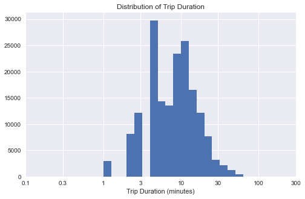

### Distribution of Age

Next, looking at Age we can see that there is a right skew with the peak beging around the 30 year age mark. You can also see that majority of users are over the age of 30.

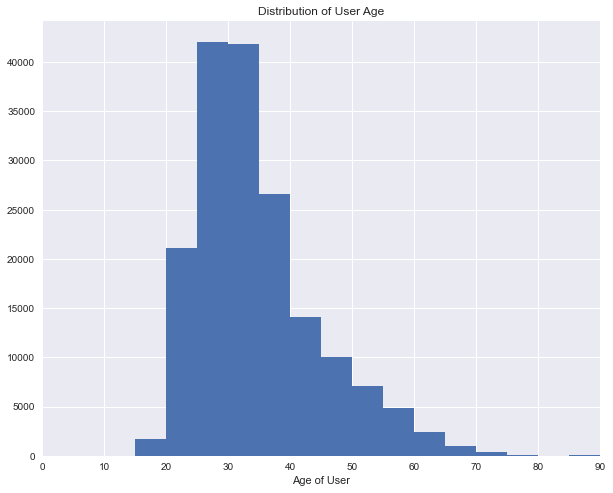

### Gender Split

As we are able to look at the users based on Gender, I thought it would be interesting to see if one uses the service more than the other. In the first visualisation, we can see that almost 74.7% of users are male whereas women make up only 23.3%.

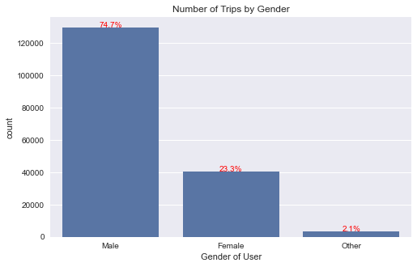

### Duration vs. Gender

Looking at a subset trips (those less than 60 minutes), we can see that there isn't too much differentation between the categories in terms of duration of trips. All three plots look very similar, with the median trip being around 10 minutes.

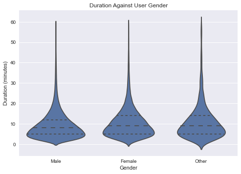

### Duration vs. Gender & Age

In the first graph showing duration by gender and age, we can see that 10-19 group took the longest trips for Men and Women. This could be done to factors such as fitness levels or potentially needing to travel further to places such as school.

We can also see that the group who took the second longest trips were those older than 50 which is suprising. This may be down to have more free time due to less commitments.

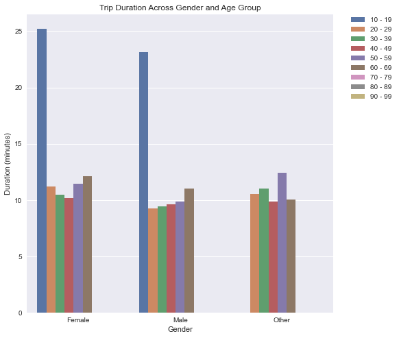

## Weekday & Weekends Traffic && Day_Time Ride frequency

Weekdays have a lot of traffic at 8:00 and 17:00 while the weekends do not have a general trend.

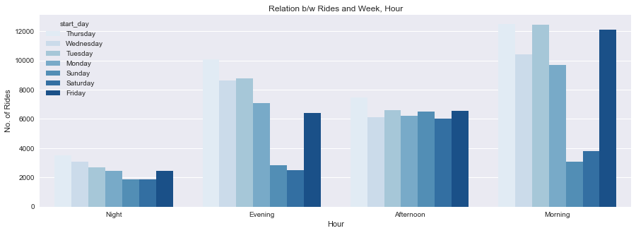

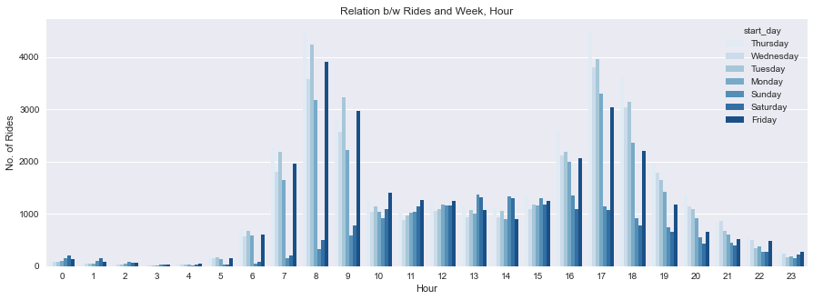

## Distribution of Users

Most of the users of the bike sharing service are Subscribers while the customers are very less

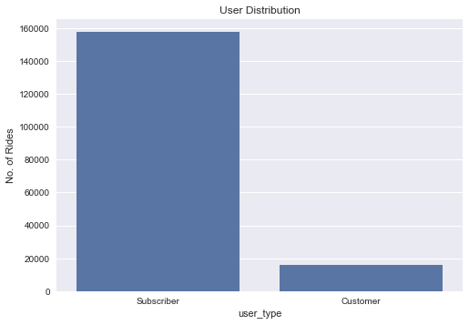